# Importing & Cleaning Data in R - Case Studies

GT

November 14, 2016

### Ticket Sales Data

Hone your skills by importing and cleaning some wonderfully messy online ticket sales data.

#### Importing the data

You’ll be importing and cleaning four real datasets that are a little messier than before. Don’t worry – you’re up for the challenge!

Your first dataset describes online ticket sales for various events across the country. It’s stored as a Comma-Separated Value (CSV) file calles `sales.csv`. Let’s jump right in!

```r
sales <- read.csv("sales.csv", stringsAsFactors = FALSE, row.names = 1)
```

#### Examining the data.

As you know from the course, the first step when preparing to clean data is to inspect it. Let’s refresh your memory on some useful functions that can do that:

- `dim()` returns the dimensions of an object
- `head()` displays the first part of an object
- `names()` returns the names associated with an object

```r
# View dimensions of sales
dim(sales)
```

```
## [1] 5000   46
```

```r
# Inspect first 6 rows of sales
head(sales)
```

```
##   X             event_id       primary_act_id     secondary_act_id
## 1 1 abcaf1adb99a935fc661 43f0436b905bfa7c2eec b85143bf51323b72e53c
## 2 2 6c56d7f08c95f2aa453c 1a3e9aecd0617706a794 f53529c5679ea6ca5a48
## 3 3 c7ab4524a121f9d687d2 4b677c3f5bec71eec8d1 b85143bf51323b72e53c
## 4 4 394cb493f893be9b9ed1 b1ccea01ad6ef8522796 b85143bf51323b72e53c
## 5 5 55b5f67e618557929f48 91c03a34b562436efa3c b85143bf51323b72e53c
## 6 6 4f10fd8b9f550352bd56 ac4b847b3fde66f2117e 63814f3d63317f1b56c4
##    purch_party_lkup_id
## 1 7dfa56dd7d5956b17587
## 2 4f9e6fc637eaf7b736c2
## 3 6c2545703bd527a7144d
## 4 527d6b1eaffc69ddd882
## 5 8bd62c394a35213bdf52
## 6 3b3a628f83135acd0676
##                                                       event_name
```

[output cut: 97 more lines]

```r
# View column names of sales
names(sales)
```

```
##  [1] "X"                      "event_id"
##  [3] "primary_act_id"         "secondary_act_id"
##  [5] "purch_party_lkup_id"    "event_name"
##  [7] "primary_act_name"       "secondary_act_name"
##  [9] "major_cat_name"         "minor_cat_name"
## [11] "la_event_type_cat"      "event_disp_name"
## [13] "ticket_text"            "tickets_purchased_qty"
## [15] "trans_face_val_amt"     "delivery_type_cd"
## [17] "event_date_time"        "event_dt"
## [19] "presale_dt"             "onsale_dt"
## [21] "sales_ord_create_dttm"  "sales_ord_tran_dt"
## [23] "print_dt"               "timezn_nm"
## [25] "venue_city"             "venue_state"
## [27] "venue_postal_cd_sgmt_1" "sales_platform_cd"
## [29] "print_flg"              "la_valid_tkt_event_flg"
## [31] "fin_mkt_nm"             "web_session_cookie_val"
## [33] "gndr_cd"                "age_yr"
## [35] "income_amt"             "edu_val"
## [37] "edu_1st_indv_val"       "edu_2nd_indv_val"
## [39] "adults_in_hh_num"       "married_ind"
## [41] "child_present_ind"      "home_owner_ind"
## [43] "occpn_val"              "occpn_1st_val"
## [45] "occpn_2nd_val"          "dist_to_ven"
```

Notice how the rows appear to represent individual purchases and the columns contain different pieces of information about each purchase.

#### Summarizing the data

Luckily, the rows and columns appear to be arranged in a meaningful way: each row represents an observation and each column a variable, or piece of information about the observation.

In R, there are a great many tools at your disposal to help get a feel for your data. Besides the three you used in the previous exercise, the functions `str()` and `summary()` can be very helpful.

The `dplyr` package, introduced previously, offers the `glimpse()` function, which can also be used for this purpose.

```r
# Look at structure of sales
str(sales)
```

```
## 'data.frame':    5000 obs. of  46 variables:
##  $ X                     : int  1 2 3 4 5 6 7 8 9 10 ...
##  $ event_id              : chr  "abcaf1adb99a935fc661" "6c56d7f08c95f2aa453c" "c7ab4524a121f9d687d2" "394cb493f893be9b9ed1" ...
##  $ primary_act_id        : chr  "43f0436b905bfa7c2eec" "1a3e9aecd0617706a794" "4b677c3f5bec71eec8d1" "b1ccea01ad6ef8522796" ...
##  $ secondary_act_id      : chr  "b85143bf51323b72e53c" "f53529c5679ea6ca5a48" "b85143bf51323b72e53c" "b85143bf51323b72e53c" ...
##  $ purch_party_lkup_id   : chr  "7dfa56dd7d5956b17587" "4f9e6fc637eaf7b736c2" "6c2545703bd527a7144d" "527d6b1eaffc69ddd882" ...
##  $ event_name            : chr  "Xfinity Center Mansfield Premier Parking: Florida Georgia Line" "Gorge Camping - dave matthews band - sept 3-7" "Dodge Theatre Adams Street Parking - benise" "Gexa Energy Pavilion Vip Parking : kid rock with sheryl crow" ...
##  $ primary_act_name      : chr  "XFINITY Center Mansfield Premier Parking" "Gorge Camping" "Parking Event" "Gexa Energy Pavilion VIP Parking" ...
##  $ secondary_act_name    : chr  "NULL" "Dave Matthews Band" "NULL" "NULL" ...
##  $ major_cat_name        : chr  "MISC" "MISC" "MISC" "MISC" ...
##  $ minor_cat_name        : chr  "PARKING" "CAMPING" "PARKING" "PARKING" ...
##  $ la_event_type_cat     : chr  "PARKING" "INVALID" "PARKING" "PARKING" ...
##  $ event_disp_name       : chr  "Xfinity Center Mansfield Premier Parking: Florida Georgia Line" "Gorge Camping - dave matthews band - sept 3-7" "Dodge Theatre Adams Street Parking - benise" "Gexa Energy Pavilion Vip Parking : kid rock with sheryl crow" ...
##  $ ticket_text           : chr  "   THIS TICKET IS VALID        FOR PARKING ONLY         GOOD THIS DAY ONLY       PREMIER PARKING PASS    XFINITY CENTER,LOTS 4 "| __truncated__ "%OVERNIGHT C A M P I N G%* * * * * *%GORGE CAMPGROUND%* GOOD THIS DATE ONLY *%SEP 3 - 6, 2009" "ADAMS STREET GARAGE%PAR…
##  $ tickets_purchased_qty : int  1 1 1 1 1 2 1 1 1 1 ...
```

[output cut: 32 more lines]

```r
# View a summary of sales
summary(sales)
```

```
##        X          event_id         primary_act_id     secondary_act_id
##  Min.   :   1   Length:5000        Length:5000        Length:5000
##  1st Qu.:1251   Class :character   Class :character   Class :character
##  Median :2500   Mode  :character   Mode  :character   Mode  :character
##  Mean   :2500
##  3rd Qu.:3750
##  Max.   :5000
##
##  purch_party_lkup_id  event_name        primary_act_name
##  Length:5000         Length:5000        Length:5000
##  Class :character    Class :character   Class :character
##  Mode  :character    Mode  :character   Mode  :character
##
##
##
##
##  secondary_act_name major_cat_name     minor_cat_name
##  Length:5000        Length:5000        Length:5000
##  Class :character   Class :character   Class :character
##  Mode  :character   Mode  :character   Mode  :character
##
##
##
##
##  la_event_type_cat  event_disp_name    ticket_text
##  Length:5000        Length:5000        Length:5000
##  Class :character   Class :character   Class :character
##  Mode  :character   Mode  :character   Mode  :character
##
##
##
##
##  tickets_purchased_qty trans_face_val_amt delivery_type_cd
##  Min.   :1.000         Min.   :   1.00    Length:5000
##  1st Qu.:1.000         1st Qu.:  20.00    Class :character
##  Median :1.000         Median :  30.00    Mode  :character
##  Mean   :1.639         Mean   :  77.08
##  3rd Qu.:2.000         3rd Qu.:  85.00
##  Max.   :8.000         Max.   :1520.88
##
```

[output cut: 65 more lines]

```
##  Length:5000        Length:5000        Length:5000
##  Class :character   Class :character   Class :character
##  Mode  :character   Mode  :character   Mode  :character
##
##
##
##
##  occpn_1st_val      occpn_2nd_val       dist_to_ven
##  Length:5000        Length:5000        Min.   :   0.0
##  Class :character   Class :character   1st Qu.:  12.0
##  Mode  :character   Mode  :character   Median :  26.0
##                                        Mean   : 158.2
##                                        3rd Qu.:  77.5
##                                        Max.   :2548.0
##                                        NA's   :4677
```

```r
# Load dplyr
library(dplyr)
# Get a glimpse of sales
glimpse(sales)
```

```
## Observations: 5,000
## Variables: 46
## $ X                      <int> 1, 2, 3, 4, 5, 6, 7, 8, 9, 10, 11, 12, ...
## $ event_id               <chr> "abcaf1adb99a935fc661", "6c56d7f08c95f2...
## $ primary_act_id         <chr> "43f0436b905bfa7c2eec", "1a3e9aecd06177...
## $ secondary_act_id       <chr> "b85143bf51323b72e53c", "f53529c5679ea6...
## $ purch_party_lkup_id    <chr> "7dfa56dd7d5956b17587", "4f9e6fc637eaf7...
## $ event_name             <chr> "Xfinity Center Mansfield Premier Parki...
## $ primary_act_name       <chr> "XFINITY Center Mansfield Premier Parki...
## $ secondary_act_name     <chr> "NULL", "Dave Matthews Band", "NULL", "...
## $ major_cat_name         <chr> "MISC", "MISC", "MISC", "MISC", "MISC",...
## $ minor_cat_name         <chr> "PARKING", "CAMPING", "PARKING", "PARKI...
## $ la_event_type_cat      <chr> "PARKING", "INVALID", "PARKING", "PARKI...
## $ event_disp_name        <chr> "Xfinity Center Mansfield Premier Parki...
## $ ticket_text            <chr> "   THIS TICKET IS VALID        FOR PAR...
```

[output cut: 33 more lines]

Before moving on, scroll to the top of `glimpse()` output. Notice the firt column, `X`, which appears to just be counting.

#### Removing redundant info

You may have noticed that the first column of data is just a duplication of the row numbers. Not very useful. Go ahead and delete that column.

Remember that `nrow()` and `ncol()` return the number of rows and columns in a data frame, respectively.

Also, recall that you can use square brackets to subset a data frame as follows:

```
my_df[1:5,]   # First 5 rows of my_df
my_df[, 4]    # Fourth column of my_df
```

Alternatively, you can remove rows and columns using negative indices. For example:

[output not shown]

```r
# Remove the first column of sales: sales2
sales2 <- sales[,-1]
```

#### Information not worth keeping

Many of the columns have information that’s of no use to us. For example, the first four columns contain internal codes representing particular events. The last fifteen columns also aren’t worth keeping: there are too many missing values to make them worthwhile.

An easy way to get rid of unnecessary columns is to create a vector containing the column indices you want to keep, then subset the data based on that vector using single bracket subsetting.

```r
# Define a vector of column indices: keep
keep <- 5:(ncol(sales2)-15)

# Subset sales2 using keep: sales3
sales3 <- sales2[,keep]
```

#### Separating columns

Some of the columns in your data frame include multiple pieces of information that should be in separate columns. In this exercise, you will separate such a column into two: one for date and one for time. You will use the `separate()` function from the `tidyr` package.

```r
# Load tidyr
library(tidyr)

# Inspect first 6 rows of sales3$event_date_time
head(sales3$event_date_time)
```

```
## [1] "2015-09-12 23:30:00" "2009-09-05 01:00:00" "2006-04-22 01:30:00"
## [4] "2011-09-03 00:00:00" "2005-07-31 01:00:00" "2012-07-22 02:00:00"
```

```r
# Split event_date_time: sales4
sales4 <- separate(sales3, event_date_time,
                   c("event_dt", "event_time"), sep = " ")

# Inspect first 6 rows of sales4$sales_ord_create_dttm
head(sales4$sales_ord_create_dttm)
```

```
## [1] "2015-09-11 18:17:45" "2009-07-06 00:00:00" "2006-04-05 00:00:00"
## [4] "2011-07-01 17:38:50" "2005-06-18 00:00:00" "2012-07-21 17:20:18"
```

```r
# Split sales_ord_create_dttm: sales5
sales5 <- separate(sales4, sales_ord_create_dttm,
                    c("ord_create_dt", "ord_create_time"), sep = " ")
```

```
## Warning: Too few values at 4 locations: 2516, 3863, 4082, 4183
```

Did you see the warning message that just popped up in the console ? No need to panic. You’ll sort it out in the next exercise.

#### Dealing with warnings

Looks like the second call to `separate()` threw a warning. Not to worry; warnings aren’t as bas as error messages. It’s not saying that the command didn’t execute; it’s just a heads-up that something unusual happened.

The warning say `Too few values at 4 locations`. You may be able to guess already what the issue is, but it’s still good to take a look.

The locations (i.e. rows) given in the warning are 2516, 3863, 4082 and 4183. Have a look at the contents of the `sales_ord_create_dttm` column in those rows.

```r
# Define an issues vector
issues <- c(2516, 3863, 4082, 4183)

# Print values of sales_ord_create_dttm at these indices
sales3$sales_ord_create_dttm[issues]
```

```
## [1] "NULL" "NULL" "NULL" "NULL"
```

```r
# Print a well-behaved value of sales_ord_create_dttm
sales3$sales_ord_create_dttm[2517]
```

```
## [1] "2013-08-04 23:07:19"
```

The warning was just because of four missing values. You’ll ignore them for now, but if your analysis depended on complete date/time information, you would probabily need to delete those rows.

#### Identifying dates

Some of the columns in your dataset contain dates of different events. Right now, they are stored as character strings. That’s fine if all you want to do is look up the date associated with an event, but if you want to do any comparisons or math with the dates, it’s MUCH easier to store them as `Date` objects.

Luckily, all of the date columns in this dataset have the substring `"dt"` in their name, so you can use the `str_detect()` function of the `stringr` package to find the date columns. Then you can coerce them to `Date` objects using a function from the `lubridate` package.

You’ll use `lapply()` to apply the appropriate `lubridate` function to all of the columns that contain dates. Recall the following syntax for `lapply()` applied to some data frame columns of interest:

```
lapply(my_data_frame[, cols], function_name)
```

Also recall that function names in `lubridate` combine the letters `y`, `m`, `d`, `h`, `m`, `s` depending on the format of the date/time string being read in.

```r
# Load stringr
library(stringr)

# Find columns of sales5 containing "dt": date_cols
date_cols = str_detect(names(sales5), "dt")

# Load lubridate
library(lubridate)
# Coerce date columns into Date objects
sales5[, date_cols] <- lapply(sales5[,date_cols], ymd)
```

```
## Warning: 2892 failed to parse.
```

```
## Warning: 101 failed to parse.
```

```
## Warning: 4 failed to parse.
```

```
## Warning: 424 failed to parse.
```

Your code looks great, but there were a few more warnings.

#### More warnings!

As you saw, some of the calls to `ymd()` caused a `failure to parse` warning. That’s probably because of more missing data, but again, it’s good to check to be sure.

The first two lines of code (provided for you here) create a list of logical vectors called `missing`. Each vector in the list indicates the presence (or absence) of missing values in the corresponding column of `sales5`. See if the number of missing values in each column is the same as the number of rows that failed to parse in the previous exercise.

```r
# Find date columns (don't change)
date_cols <- str_detect(names(sales5), "dt")

# Create logical vectors indicating missing values (don't change)
missing <- lapply(sales5[, date_cols], is.na)

# Create a numerical vector that counts missing values: num_missing
num_missing <- sapply(missing, sum)

# Print num_missing
num_missing
```

```
##          event_dt        event_dt.1        presale_dt         onsale_dt
##                 0                 0              2892               101
##     ord_create_dt sales_ord_tran_dt          print_dt
##                 4                 0               424
```

#### Combining columns

Sure enough, the number of `NA` in each column match the numbers from the warning messages, so missing data is the culprit. How to proceed depends on your desider analysis. If you really need complete sets of date/time information, you might delete the rows or columns containing `NA`.

As your last step, you’ll use the `tidyr` function `unite()` to combine the `venue_city` and `vanue_state` columns into one column with the two values separated by a comma and a space. For example, `"PORTLAND"` `"MAINE"` should become `"PORTLAND, MAINE"`.

```r
# Combine the venue_city and venue_state columns
sales6 <- unite(sales5, venue_city_state, venue_city, venue_state, sep = ", ")

# View the head of sales6
head(sales6)
```

```
##                                                       event_name
## 1 Xfinity Center Mansfield Premier Parking: Florida Georgia Line
## 2                  Gorge Camping - dave matthews band - sept 3-7
## 3                    Dodge Theatre Adams Street Parking - benise
## 4   Gexa Energy Pavilion Vip Parking : kid rock with sheryl crow
## 5                                  Premier Parking - motley crue
## 6                                      Fast Lane Access: Journey
##                           primary_act_name secondary_act_name
## 1 XFINITY Center Mansfield Premier Parking               NULL
## 2                            Gorge Camping Dave Matthews Band
## 3                            Parking Event               NULL
## 4         Gexa Energy Pavilion VIP Parking               NULL
## 5 White River Amphitheatre Premier Parking               NULL
## 6                         Fast Lane Access            Journey
##   major_cat_name         minor_cat_name la_event_type_cat
```

[output cut: 55 more lines]

This dataset is mucch cleaner. Your next steps would depend on what specific analyses you wanted to perform.

### MBTA Ridership Data

Boston’s public transit system needs your help! The T wants to do some data analysis and you’ve been asked to clean their ridership data.

#### Using readx!

The Massachusetts Bay Transportation Authority (“MBTA” or just “the T” for short) manages America’s oldest subway, as well as Greater Boston’s commuter rail, ferry and bus systems.

It’s your first day on the job as the T’s data analyst and you’ve been tasked with analyzing average ridership through time. You’re in luck, because this chapter of the course will guide you through cleaning a set of MBTA ridership data!

The dataset is stored as an Excel spreadsheet called `mbta.xlsx` in your working directory. You’ll use the `read_excel()` function from Hadley Wickham’s `readxl` package to import it.

The first time you import a dataset, you might not know how many rows need to be skipped. In this case, the first row it a title, so you’ll need to skip the first row.

```r
# Load readxl
library(readxl)

# Import mbta.xlsx and skip first row: mbta
mbta <- read_excel("mbta.xlsx", skip = 1)
```

#### Examining the dataa

Your new boss at the T has tasked you with analyzing the ridership data. Of course, you’re going to clean the dataset first. The first step when cleaning a dataset it to explore it a bit.

The `mbta` data frame is already loaded in your workspace. Pay particular attention to how the rows and columns are organized and to the location of missing values.

```r
# View the structure of mbta
str(mbta)
```

```
## Classes 'tbl_df', 'tbl' and 'data.frame':    11 obs. of  60 variables:
##  $        : num  1 2 3 4 5 6 7 8 9 10 ...
##  $ mode   : chr  "All Modes by Qtr" "Boat" "Bus" "Commuter Rail" ...
##  $ 2007-01: chr  "NA" "4" "335.819" "142.2" ...
##  $ 2007-02: chr  "NA" "3.6" "338.675" "138.5" ...
##  $ 2007-03: num  1188 40 340 138 459 ...
##  $ 2007-04: chr  "NA" "4.3" "352.162" "139.5" ...
##  $ 2007-05: chr  "NA" "4.9" "354.367" "139" ...
##  $ 2007-06: num  1246 5.8 350.5 143 477 ...
##  $ 2007-07: chr  "NA" "6.521" "357.519" "142.391" ...
##  $ 2007-08: chr  "NA" "6.572" "355.479" "142.364" ...
##  $ 2007-09: num  1256.57 5.47 372.6 143.05 499.57 ...
##  $ 2007-10: chr  "NA" "5.145" "368.847" "146.542" ...
##  $ 2007-11: chr  "NA" "3.763" "330.826" "145.089" ...
##  $ 2007-12: num  1216.89 2.98 312.92 141.59 448.27 ...
```

[output cut: 46 more lines]

```r
# View the first 6 rows of mbta
head(mbta)
```

```
## # A tibble: 6 × 60
##      ``             mode `2007-01` `2007-02` `2007-03` `2007-04` `2007-05`
##   <dbl>            <chr>     <chr>     <chr>     <dbl>     <chr>     <chr>
## 1     1 All Modes by Qtr        NA        NA  1187.653        NA        NA
## 2     2             Boat         4       3.6    40.000       4.3       4.9
## 3     3              Bus   335.819   338.675   339.867   352.162   354.367
## 4     4    Commuter Rail     142.2     138.5   137.700     139.5       139
## 5     5       Heavy Rail   435.294   448.271   458.583   472.201   474.579
## 6     6       Light Rail   227.231   240.262   241.444   255.557   248.262
## # ... with 53 more variables: `2007-06` <dbl>, `2007-07` <chr>,
## #   `2007-08` <chr>, `2007-09` <dbl>, `2007-10` <chr>, `2007-11` <chr>,
## #   `2007-12` <dbl>, `2008-01` <chr>, `2008-02` <chr>, `2008-03` <dbl>,
## #   `2008-04` <chr>, `2008-05` <chr>, `2008-06` <dbl>, `2008-07` <chr>,
## #   `2008-08` <chr>, `2008-09` <dbl>, `2008-10` <chr>, `2008-11` <chr>,
## #   `2008-12` <dbl>, `2009-01` <chr>, `2009-02` <chr>, `2009-03` <dbl>,
## #   `2009-04` <chr>, `2009-05` <chr>, `2009-06` <dbl>, `2009-07` <chr>,
## #   `2009-08` <chr>, `2009-09` <dbl>, `2009-10` <chr>, `2009-11` <chr>,
## #   `2009-12` <dbl>, `2010-01` <chr>, `2010-02` <chr>, `2010-03` <dbl>,
## #   `2010-04` <chr>, `2010-05` <chr>, `2010-06` <dbl>, `2010-07` <chr>,
## #   `2010-08` <chr>, `2010-09` <dbl>, `2010-10` <chr>, `2010-11` <chr>,
## #   `2010-12` <dbl>, `2011-01` <chr>, `2011-02` <chr>, `2011-03` <dbl>,
## #   `2011-04` <chr>, `2011-05` <chr>, `2011-06` <dbl>, `2011-07` <chr>,
## #   `2011-08` <chr>, `2011-09` <dbl>, `2011-10` <chr>
```

```r
# View a summary of mbta
summary(mbta)
```

```
##                     mode             2007-01            2007-02
##  Min.   : 1.0   Length:11          Length:11          Length:11
##  1st Qu.: 3.5   Class :character   Class :character   Class :character
##  Median : 6.0   Mode  :character   Mode  :character   Mode  :character
##  Mean   : 6.0
##  3rd Qu.: 8.5
##  Max.   :11.0
##     2007-03           2007-04            2007-05
##  Min.   :   0.114   Length:11          Length:11
##  1st Qu.:   9.278   Class :character   Class :character
##  Median : 137.700   Mode  :character   Mode  :character
##  Mean   : 330.293
##  3rd Qu.: 399.225
##  Max.   :1204.725
##     2007-06           2007-07            2007-08
##  Min.   :   0.096   Length:11          Length:11
##  1st Qu.:   5.700   Class :character   Class :character
##  Median : 143.000   Mode  :character   Mode  :character
##  Mean   : 339.846
##  3rd Qu.: 413.788
##  Max.   :1246.129
##     2007-09           2007-10            2007-11
##  Min.   :  -0.007   Length:11          Length:11
##  1st Qu.:   5.539   Class :character   Class :character
##  Median : 143.051   Mode  :character   Mode  :character
##  Mean   : 352.554
##  3rd Qu.: 436.082
##  Max.   :1310.764
##     2007-12           2008-01            2008-02
##  Min.   :  -0.060   Length:11          Length:11
##  1st Qu.:   4.385   Class :character   Class :character
##  Median : 141.585   Mode  :character   Mode  :character
##  Mean   : 321.588
##  3rd Qu.: 380.594
##  Max.   :1216.890
##     2008-03           2008-04            2008-05
##  Min.   :   0.058   Length:11          Length:11
##  1st Qu.:   5.170   Class :character   Class :character
##  Median : 137.453   Mode  :character   Mode  :character
##  Mean   : 345.604
```

[output cut: 85 more lines]

```
##  Max.   :1286.66
##     2011-06           2011-07            2011-08
##  Min.   :   0.054   Length:11          Length:11
##  1st Qu.:   6.926   Class :character   Class :character
##  Median : 135.581   Mode  :character   Mode  :character
##  Mean   : 353.331
##  3rd Qu.: 452.923
##  Max.   :1302.414
##     2011-09           2011-10
##  Min.   :   0.043   Length:11
##  1st Qu.:   6.660   Class :character
##  Median : 136.901   Mode  :character
##  Mean   : 362.555
##  3rd Qu.: 469.204
##  Max.   :1348.754
```

Do you notice anything strange about how the rows and columns are organized ?

#### Removing unnecessary rows and columns

It appears that the data are organized with observations stored as columns rather than as rows. You can fix that.

First, though, you can address the missing data. All of the `NA` values are storedin the `All Modes by Qtr` row. This row really belongs in a different data frame; it is a quarterly average of weekday MBTA ridership. Since this dataset tracks monthly average ridership, you’ll remove that row.

Similarly, the 7th row (`Pct Chg / Yr`) and the 11th row (`TOTAL`) are not really observations as much as they are analysis. Go ahead and remove the 7th and 11th rows as well.

The first column also needs to be removed because it’s just listing the row numbers.

In case you were wondering, this dataset is stored as a `tibble` which is just a specific type of data frame.

```r
# Remove rows 1, 7, and 11 of mbta: mbta2
mbta2 <- mbta[-c(1,7,11),]

# Remove the first column of mbta2: mbta3
mbta3 <- mbta2[,-1]
```

#### Observations are stored in columns

Recall from a few exercises back that in your T ridership data, variables are stored in rows instead of columns.

The different modes of transportation (commuter rail, bus, subway, ferry, …) are **variables**, providing information about each month’s average ridership. The months themselves are **observations**. You can tell which is which because as you go through time, the month changes, but the modes of transport offered by the T do not.

As is customary, you want to represent variables in columns rather than rows. The first step is to uset the `gather()` function from the `tidyr` package, which will gather columns into key-value pairs.

```r
# Load tidyr
library(tidyr)

# Gather columns of mbta3: mbta4
mbta4 <- gather(mbta3, month, thou_riders, -mode)

# View the head of mbta4
head(mbta4)
```

```
## # A tibble: 6 × 3
##            mode   month thou_riders
##           <chr>   <chr>       <chr>
## 1          Boat 2007-01           4
## 2           Bus 2007-01     335.819
## 3 Commuter Rail 2007-01       142.2
## 4    Heavy Rail 2007-01     435.294
## 5    Light Rail 2007-01     227.231
## 6   Private Bus 2007-01       4.772
```

Your dataset is **long** now - notice that the first column still stores variable names , but now, months have their column instead of being headers. Also notice the data type in each column.

#### Type conversions

In a minute, you’ll put variables where they belong (as column names). But first, take this oppurtunity to change the average weekday ridership column, `thou_riders`, into numeric values rather than character strings. That way, you’ll be able to do things like compare values and do math.

```r
# Coerce thou_riders to numeric
mbta4$thou_riders <- as.numeric(mbta4$thou_riders)
```

#### Variables are stored in both rows and colums

Now, you can finish the job you started earlier: getting variables into columns. Right now, variables are stored as “keys” in the `mode` column. You’ll use the `tidyr` function `spread()` to make them into columns containing average weekday ridership for the given month and mode of transport.

```r
# Spread the contents of mbta4: mbta5
mbta5 <- spread(mbta4, mode, thou_riders)

# View the head of mbta5
head(mbta5)
```

```
## # A tibble: 6 × 9
##     month  Boat     Bus `Commuter Rail` `Heavy Rail` `Light Rail`
##     <chr> <dbl>   <dbl>           <dbl>        <dbl>        <dbl>
## 1 2007-01   4.0 335.819           142.2      435.294      227.231
## 2 2007-02   3.6 338.675           138.5      448.271      240.262
## 3 2007-03  40.0 339.867           137.7      458.583      241.444
## 4 2007-04   4.3 352.162           139.5      472.201      255.557
## 5 2007-05   4.9 354.367           139.0      474.579      248.262
## 6 2007-06   5.8 350.543           143.0      477.032      246.108
## # ... with 3 more variables: `Private Bus` <dbl>, RIDE <dbl>, `Trackless
## #   Trolley` <dbl>
```

#### Separating columns

Your dataset is already looking much better! Your boss saw what a great job you’re doing and now wants you to do an analysis of the T’s ridership during certain months across all years.

Your dataset has month names in it, so that analysis will be a piece of cake. There’s only one small problem: if you want to look at ridership on the T during every January (for example), the month and year are together in the same column, which makes it a little tricky.

In this exercise, you’ll separate the `month` column into distinct `month` and `year` columns to make life easier.

```r
# View the head of mbta5
head(mbta5)
```

```
## # A tibble: 6 × 9
##     month  Boat     Bus `Commuter Rail` `Heavy Rail` `Light Rail`
##     <chr> <dbl>   <dbl>           <dbl>        <dbl>        <dbl>
## 1 2007-01   4.0 335.819           142.2      435.294      227.231
## 2 2007-02   3.6 338.675           138.5      448.271      240.262
## 3 2007-03  40.0 339.867           137.7      458.583      241.444
## 4 2007-04   4.3 352.162           139.5      472.201      255.557
## 5 2007-05   4.9 354.367           139.0      474.579      248.262
## 6 2007-06   5.8 350.543           143.0      477.032      246.108
## # ... with 3 more variables: `Private Bus` <dbl>, RIDE <dbl>, `Trackless
## #   Trolley` <dbl>
```

```r
# Split month column into month and year: mbta6
mbta6 <- separate(mbta5, month, c("year", "month"), sep = "-")

# View the head of mbta6
head(mbta6)
```

```
## # A tibble: 6 × 10
##    year month  Boat     Bus `Commuter Rail` `Heavy Rail` `Light Rail`
##   <chr> <chr> <dbl>   <dbl>           <dbl>        <dbl>        <dbl>
## 1  2007    01   4.0 335.819           142.2      435.294      227.231
## 2  2007    02   3.6 338.675           138.5      448.271      240.262
## 3  2007    03  40.0 339.867           137.7      458.583      241.444
## 4  2007    04   4.3 352.162           139.5      472.201      255.557
## 5  2007    05   4.9 354.367           139.0      474.579      248.262
## 6  2007    06   5.8 350.543           143.0      477.032      246.108
## # ... with 3 more variables: `Private Bus` <dbl>, RIDE <dbl>, `Trackless
## #   Trolley` <dbl>
```

#### Do your values seem reasonable ?

Before you write up the analysis for your boss, it’s a good idea to screen the data for any obvious mistakes and/or outliers.

There are many valid techniques for doing this.

```r
# View a summary of mbta6
summary(mbta6)
```

```
##      year              month                Boat             Bus
##  Length:58          Length:58          Min.   : 2.985   Min.   :312.9
##  Class :character   Class :character   1st Qu.: 3.494   1st Qu.:345.6
##  Mode  :character   Mode  :character   Median : 4.293   Median :359.9
##                                        Mean   : 5.068   Mean   :358.6
##                                        3rd Qu.: 5.356   3rd Qu.:372.2
##                                        Max.   :40.000   Max.   :398.5
##  Commuter Rail     Heavy Rail      Light Rail     Private Bus
##  Min.   :121.4   Min.   :435.3   Min.   :194.4   Min.   :2.213
##  1st Qu.:131.4   1st Qu.:471.1   1st Qu.:220.6   1st Qu.:2.641
##  Median :138.8   Median :487.3   Median :231.9   Median :2.820
##  Mean   :137.4   Mean   :489.3   Mean   :233.0   Mean   :3.352
##  3rd Qu.:142.4   3rd Qu.:511.3   3rd Qu.:244.5   3rd Qu.:4.167
##  Max.   :153.0   Max.   :554.9   Max.   :271.1   Max.   :4.878
##       RIDE       Trackless Trolley
##  Min.   :4.900   Min.   : 5.777
##  1st Qu.:5.965   1st Qu.:11.679
##  Median :6.615   Median :12.598
##  Mean   :6.604   Mean   :12.125
##  3rd Qu.:7.149   3rd Qu.:13.320
##  Max.   :8.598   Max.   :15.109
```

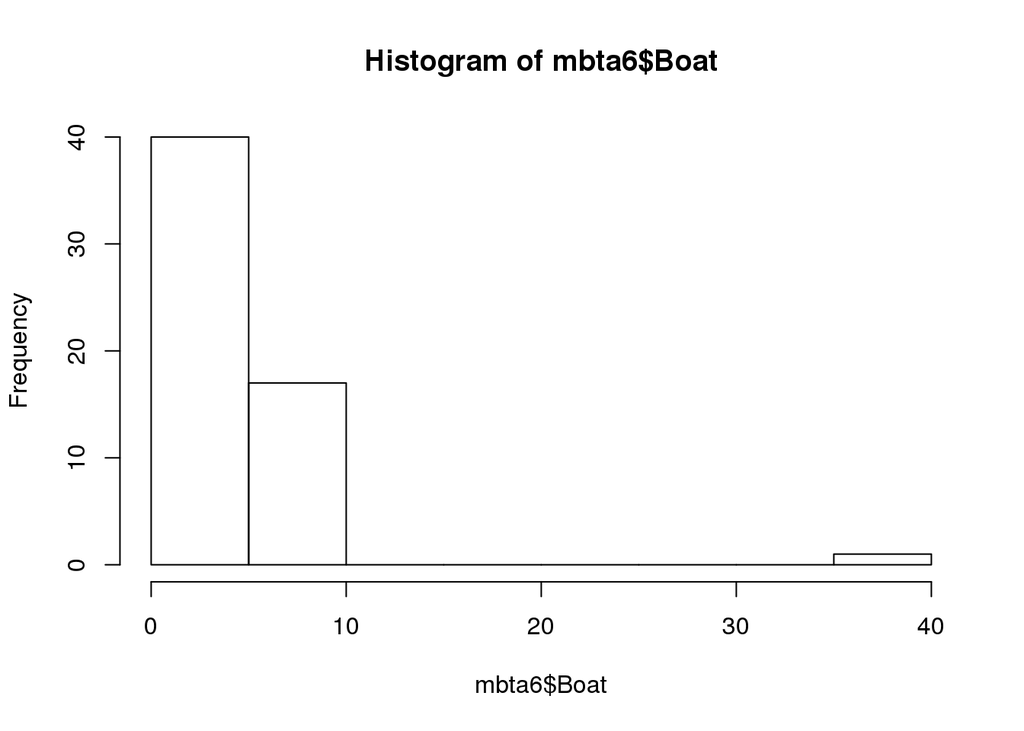

```r
# Generate a histogram of Boat ridership
hist(mbta6$Boat)
```

#### Dealing with entry error

Think for a minute about that `Boat` histogram. Every month, average weekday coomuter boat ridership was on either side of four thousand. Then, one month it jumped to 40 thousand without warning ?

Unless the Oympics were happening in Boston that month, this value is certainly an error. You can assume that whoever was entering the data that month accidentally typed `40` instead of `4`.

Because it’s error, you don’t want this value influencing your analysis. In this exercise, you’ll locate the incorrect value and change it to `4`.

After you make the change, you’ll run the last two commands in the editor as-is. They use function you may not know yet to produce some cool ridership plots: one showing the lesser-used modes of transport (take a look at gorgeous seasonal variation in Boat ridership), and one showing all modes of transport. The plots are based on the long version of the data we produced in Exercise 4 – a good example of using different data formats for different purposes.

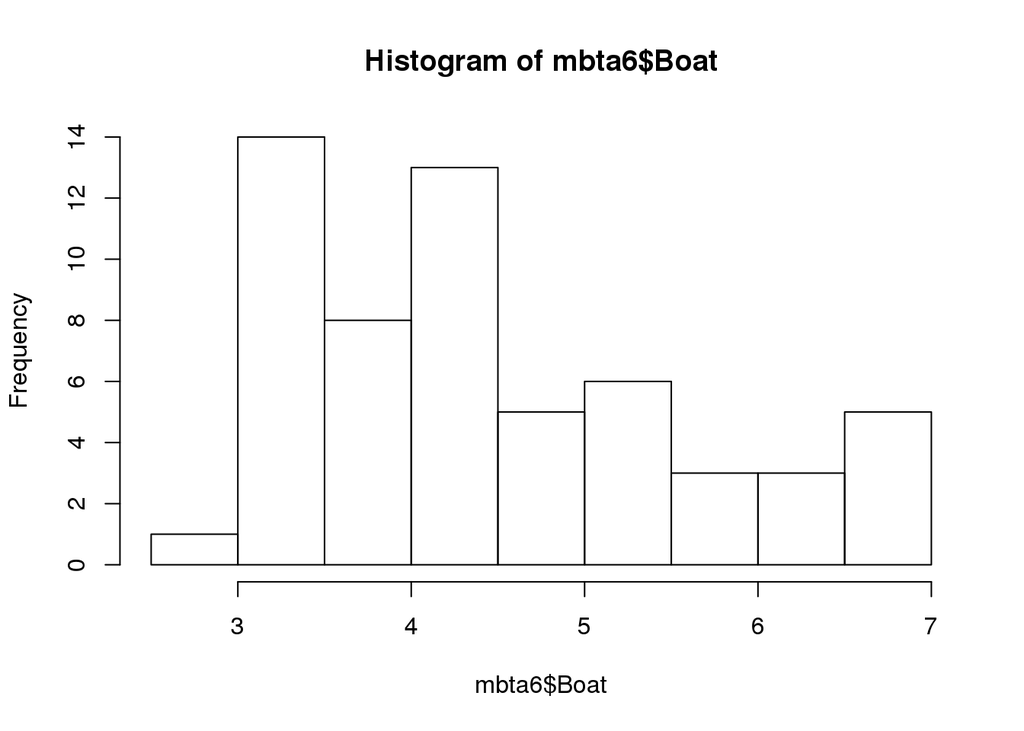

```r
# Find the row number of the incorrect value: i
i <- which(mbta6$Boat > 10 )

# Replace the incorrect value with 4
mbta6$Boat[i] <- 4

# Generate a histogram of Boat column
hist(mbta6$Boat)

library(ggplot2)
```

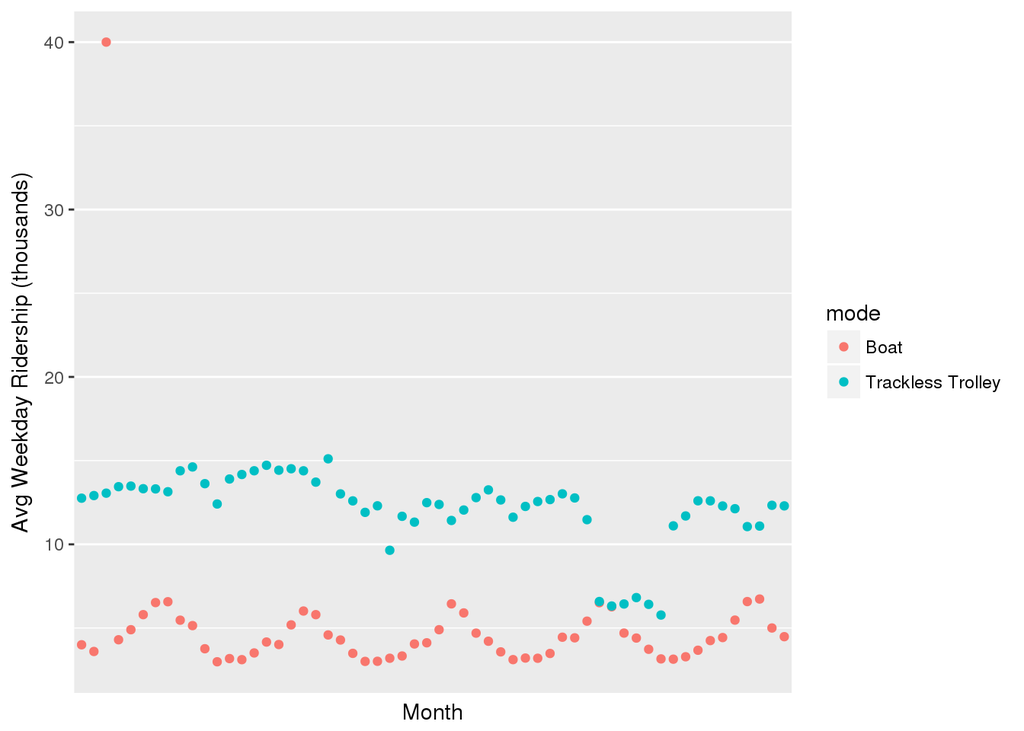

```r
mbta_boat <- subset(mbta4, mode %in% c("Boat", "Trackless Trolley"))
# Look at Boat and Trackless Trolley ridership over time (don't change)
ggplot(mbta_boat, aes(x = month, y = thou_riders, col = mode)) +  geom_point() +
  scale_x_discrete(name = "Month", breaks = c(200701, 200801, 200901, 201001, 201101)) +
  scale_y_continuous(name = "Avg Weekday Ridership (thousands)")
```

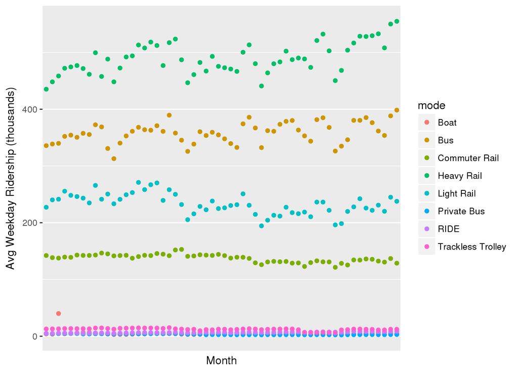

```r
mbta_all <- mbta4
# Look at all T ridership over time (don't change)
ggplot(mbta_all, aes(x = month, y = thou_riders, col = mode)) + geom_point() +
  scale_x_discrete(name = "Month", breaks = c(200701, 200801, 200901, 201001, 201101)) +
  scale_y_continuous(name = "Avg Weekday Ridership (thousands)")
```

### World Food Facts

We all know that you are what you eat, so what exactly are you? In this chapter, you’ll import and clean some data about food products from around the world.

#### Importing the data

As a person of many talents, it’s time to take on a different job: nutritional analysis! Your goal is to analyze the sugar content of a sample of foods from around the world.

A large dataset called `food.csv` is ready for your use in the working directory. Instead of the usual `read.csv()`, however, you’re going to use the faster `fread()` from the `data.table` package. The data will come in as a data table, but since you’re used to working with data frames, you can just convert it.

```r
# Load data.table
library(data.table)
# Import food.csv: food
food <- fread("food.csv")
# Convert food to a data frame
food <- data.frame(food)
food <- food[,-1]
dim(food)
```

```
## [1] 1500  160
```

#### Examining the data

As usual, you’ll need to get an idea of what the dataset looks like in order to know how to proceed.

```r
# View summary of food
summary(food)
```

```
##       V1                 code       url              creator
##  Length:1500        Min.   :0   Length:1500        Length:1500
##  Class :character   1st Qu.:0   Class :character   Class :character
##  Mode  :character   Median :0   Mode  :character   Mode  :character
##                     Mean   :0
##                     3rd Qu.:0
##                     Max.   :0
##
##   created_t         created_datetime   last_modified_t
##  Length:1500        Length:1500        Length:1500
##  Class :character   Class :character   Class :character
##  Mode  :character   Mode  :character   Mode  :character
##
##
##
##
##  last_modified_datetime product_name       generic_name
##  Length:1500            Length:1500        Length:1500
##  Class :character       Class :character   Class :character
##  Mode  :character       Mode  :character   Mode  :character
##
##
##
##
##    quantity          packaging         packaging_tags
##  Length:1500        Length:1500        Length:1500
##  Class :character   Class :character   Class :character
##  Mode  :character   Mode  :character   Mode  :character
##
##
##
##
##     brands          brands_tags         categories
##  Length:1500        Length:1500        Length:1500
##  Class :character   Class :character   Class :character
##  Mode  :character   Mode  :character   Mode  :character
##
##
##
##
```

[output cut: 337 more lines]

```
##  Min.   :12.00                    Min.   :30     Mode:logical
##  1st Qu.:13.50                    1st Qu.:47     NA's:1500
##  Median :15.00                    Median :60
##  Mean   :15.67                    Mean   :57
##  3rd Qu.:17.50                    3rd Qu.:70
##  Max.   :20.00                    Max.   :81
##  NA's   :1497                     NA's   :1491
##  carbon_footprint_100g nutrition_score_fr_100g nutrition_score_uk_100g
##  Min.   : 12.00        Min.   :-12.000         Min.   :-12.000
##  1st Qu.: 97.42        1st Qu.:  1.000         1st Qu.:  0.000
##  Median :182.85        Median :  7.000         Median :  6.000
##  Mean   :131.18        Mean   :  7.941         Mean   :  7.631
##  3rd Qu.:190.78        3rd Qu.: 15.000         3rd Qu.: 16.000
##  Max.   :198.70        Max.   : 28.000         Max.   : 28.000
##  NA's   :1497          NA's   :825             NA's   :825
```

```r
# View head of food
head(food)
```

```
##   V1          code
## 1  1 1.592115e-311
## 2  2 2.673378e-311
## 3  3 1.613001e-311
## 4  4 3.955509e-311
## 5  5 4.189677e-311
## 6  6 4.333113e-313
##                                                                                                                            url
## 1 http://world-en.openfoodfacts.org/product/3222475745867/confiture-de-fraise-fraise-des-bois-au-sucre-de-canne-casino-delices
## 2                                         http://world-en.openfoodfacts.org/product/5410976880110/guylian-sea-shells-selection
## 3                                  http://world-en.openfoodfacts.org/product/3264750423503/pates-de-fruits-aromatisees-jacquot
## 4                                  http://world-en.openfoodfacts.org/product/8006040247001/nata-vegetal-a-base-de-soja-valsoia
## 5           http://world-en.openfoodfacts.org/product/8480000340764/semillas-de-girasol-con-cascara-tostadas-aguasal-hacendado
## 6                                                           http://world-en.openfoodfacts.org/product/0087703177727/soft-drink
##       creator  created_t     created_datetime last_modified_t
```

[output cut: 447 more lines]

```r
# View structure of food
str(food)
```

```
## 'data.frame':    1500 obs. of  160 variables:
##  $ V1                                        : chr  "1" "2" "3" "4" ...
##  $ code                                      : num  1.59e-311 2.67e-311 1.61e-311 3.96e-311 4.19e-311 ...
##  $ url                                       : chr  "http://world-en.openfoodfacts.org/product/3222475745867/confiture-de-fraise-fraise-des-bois-au-sucre-de-canne-casino-delices" "http://world-en.openfoodfacts.org/product/5410976880110/guylian-sea-shells-selection" "http://world-en.openfoodfacts.…
##  $ creator                                   : chr  "sebleouf" "foodorigins" "domdom26" "javichu" ...
##  $ created_t                                 : chr  "1424747544" "1450316429" "1428674916" "1420416591" ...
##  $ created_datetime                          : chr  "2015-02-24T03:12:24Z" "2015-12-17T01:40:29Z" "2015-04-10T14:08:36Z" "2015-01-05T00:09:51Z" ...
##  $ last_modified_t                           : chr  "1438445887" "1450817956" "1428739289" "1420417876" ...
##  $ last_modified_datetime                    : chr  "2015-08-01T16:18:07Z" "2015-12-22T20:59:16Z" "2015-04-11T08:01:29Z" "2015-01-05T00:31:16Z" ...
##  $ product_name                              : chr  "Confiture de fraise fraise des bois au sucre de canne" "Guylian Sea Shells Selection" "P��tes de fruits aromatis��es" "Nata vegetal a base de soja &quot;Valsoia&quot;" ...
##  $ generic_name                              : chr  "" "" "P��tes de fruits" "Nata vegetal a base de soja" ...
##  $ quantity                                  : chr  "265 g" "375g" "1 kg" "200 ml" ...
##  $ packaging                                 : chr  "Bocal,Verre" "Plastic,Box" "Carton,plastique" "Tetra Brik" ...
##  $ packaging_tags                            : chr  "bocal,verre" "plastic,box" "carton,plastique" "tetra-brik" ...
##  $ brands                                    : chr  "Casino D��lices" "Guylian" "Jacquot" "Valsoia,//Propiedad de://,Valsoia S.p.A." ...
```

[output cut: 86 more lines]

With datasets this big, it’s hard to get a handle on exactly what they contain.

#### Inspecting variables

The `str()`, `head()` and `summary()` functions are designed to give you some information about a dataset without being overwhelming. However, this dataset is so large and has so many variables that even these outputs seemed pretty intimidating!

The `glimpse()` function from the `dplyr` package often formats information in a more approacheble way.

Yet another option is to just look at the column names to see what kinds of data you have. As you look at the names, pay particular attention to any pairs that look like duplicates.

```r
# Load dplyr
library(dplyr)

# View a glimpse of food
glimpse(food)
```

```
## Observations: 1,500
## Variables: 160
## $ V1                                         <chr> "1", "2", "3", "4",...
## $ code                                       <dbl> 1.592115e-311, 2.67...
## $ url                                        <chr> "http://world-en.op...
## $ creator                                    <chr> "sebleouf", "foodor...
## $ created_t                                  <chr> "1424747544", "1450...
## $ created_datetime                           <chr> "2015-02-24T03:12:2...
## $ last_modified_t                            <chr> "1438445887", "1450...
## $ last_modified_datetime                     <chr> "2015-08-01T16:18:0...
## $ product_name                               <chr> "Confiture de frais...
## $ generic_name                               <chr> "", "", "P��tes de ...
## $ quantity                                   <chr> "265 g", "375g", "1...
## $ packaging                                  <chr> "Bocal,Verre", "Pla...
## $ packaging_tags                             <chr> "bocal,verre", "pla...
```

[output cut: 147 more lines]

```r
# View column names of food
names(food)
```

```
##   [1] "V1"
##   [2] "code"
##   [3] "url"
##   [4] "creator"
##   [5] "created_t"
##   [6] "created_datetime"
##   [7] "last_modified_t"
##   [8] "last_modified_datetime"
##   [9] "product_name"
##  [10] "generic_name"
##  [11] "quantity"
##  [12] "packaging"
##  [13] "packaging_tags"
##  [14] "brands"
##  [15] "brands_tags"
```

[output cut: 145 more lines]

#### Removing duplicate Info

Wow. That’s a lot of variables. To summarize, there’s some information on what and when information was added(1:9), meta information about food (10:17, 22, 27), where it come from (18:21, 28:34), what it’s made of (35:52), nutrition grade (53:54), som unclear (55:63), and some nutritional information (64:159).

There are also many different pairs of columns that contain duplicate information. Luckily, you have a trusty assistant who went through and identified duplicate columns for you.

A vector has been created for you that lists out all of the duplicates; all you need to do is remove those columns from the dataset. Don’t forget, you can use the `-` operator to specify columns to omit, e.g.:

```
my_df[, -3] # Omit third column
```

```r
# Define vector of duplicate cols (don't change)
duplicates <- c(4, 6, 11, 13, 15, 17, 18, 20, 22,
                24, 25, 28, 32, 34, 36, 38, 40,
                44, 46, 48, 51, 54, 65, 158)

# Remove duplicates from food: food2
food2 <- food[, -duplicates]
```

#### Removing useless Info

Your dataset is much more manageable already.

In addition to duplicate columns, there are many columns containing information that you just can’t use. For example, the first few columns contain internal codes that don’t have any meaning to us. There are also some column names that aren’t clear enough to tell what they contain.

All of these columns can be deleted. Once again, your assistant did a splendid job finding the indices for you.

```r
# Define useless vector (don't change)
useless <- c(1, 2, 3, 32:41)

# Remove useless columns from food2: food3
food3 <- food2[, - useless]
```

#### Finding columns

Looking much nicer! Recall from the first exercise that you are assuming you will be analyzing the sugar content of these foods. Therefore, your next step is to look at a summary of the nutrition information.

All of the columns with nutrition info contain the character string `"100g"` as part of their name, which makes it easy to identify them.

```r
# Load stringr
library(stringr)

# Create vector of column indices: nutrition
nutrition <- str_detect(names(food3), "100g")

# View a summary of nutrition columns
summary(food3[,nutrition])
```

```
##  energy_from_fat_100g    fat_100g      saturated_fat_100g
##  Min.   :   0.00      Min.   :  0.00   Min.   : 0.000
##  1st Qu.:  35.98      1st Qu.:  0.90   1st Qu.: 0.200
##  Median : 237.00      Median :  6.00   Median : 1.700
##  Mean   : 668.41      Mean   : 13.39   Mean   : 4.874
##  3rd Qu.: 974.00      3rd Qu.: 20.00   3rd Qu.: 6.500
##  Max.   :2900.00      Max.   :100.00   Max.   :57.000
##  NA's   :1486         NA's   :708      NA's   :797
##  butyric_acid_100g caproic_acid_100g caprylic_acid_100g capric_acid_100g
##  Mode:logical      Mode:logical      Mode:logical       Mode:logical
##  NA's:1500         NA's:1500         NA's:1500          NA's:1500
##
##
##
##
##
##  lauric_acid_100g myristic_acid_100g palmitic_acid_100g stearic_acid_100g
##  Mode:logical     Mode:logical       Mode:logical       Mode:logical
##  NA's:1500        NA's:1500          NA's:1500          NA's:1500
##
##
##
##
##
##  arachidic_acid_100g behenic_acid_100g lignoceric_acid_100g
##  Mode:logical        Mode:logical      Mode:logical
##  NA's:1500           NA's:1500         NA's:1500
##
##
##
##
##
##  cerotic_acid_100g montanic_acid_100g melissic_acid_100g
##  Mode:logical      Mode:logical       Mode:logical
##  NA's:1500         NA's:1500          NA's:1500
##
##
##
##
##
```

[output cut: 161 more lines]

```
##  Min.   :12.00                    Min.   :30     Mode:logical
##  1st Qu.:13.50                    1st Qu.:47     NA's:1500
##  Median :15.00                    Median :60
##  Mean   :15.67                    Mean   :57
##  3rd Qu.:17.50                    3rd Qu.:70
##  Max.   :20.00                    Max.   :81
##  NA's   :1497                     NA's   :1491
##  nutrition_score_fr_100g nutrition_score_uk_100g
##  Min.   :-12.000         Min.   :-12.000
##  1st Qu.:  1.000         1st Qu.:  0.000
##  Median :  7.000         Median :  6.000
##  Mean   :  7.941         Mean   :  7.631
##  3rd Qu.: 15.000         3rd Qu.: 16.000
##  Max.   : 28.000         Max.   : 28.000
##  NA's   :825             NA's   :825
```

#### Replacing missing values

Unfortunately, the summary revealed that the nutrition data are mostly `NA` values. After consulting with the lab technician, it appears that much of the data is missing because the food just doesn’t have those nutrients.

But all is not lost! The lab tech also said that for sugar content, zero values are sometimes entered explicitly, but sometimes the values are just left empty to denote a zero. A statistical miracle!

In this exercise, you’ll replace all `NA` values with zeroes in the `sugar_100g` column and make histograms to visualize the result. Then, you will exclude the observations which have no sugar to see how the distribution changes.

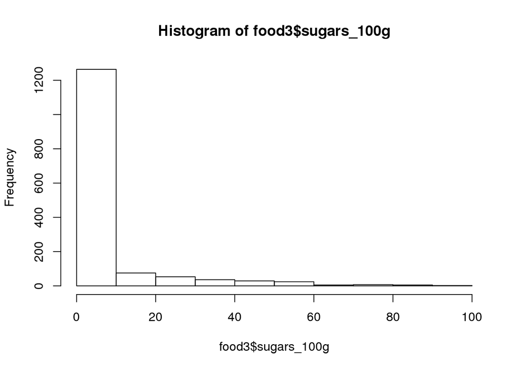

```r
# Find indices of sugar NA values: missing
missing <- is.na(food3$sugars_100g)

# Replace NA values with 0
food3$sugars_100g[missing] <- 0

# Create first histogram
hist(food3$sugars_100g)
```

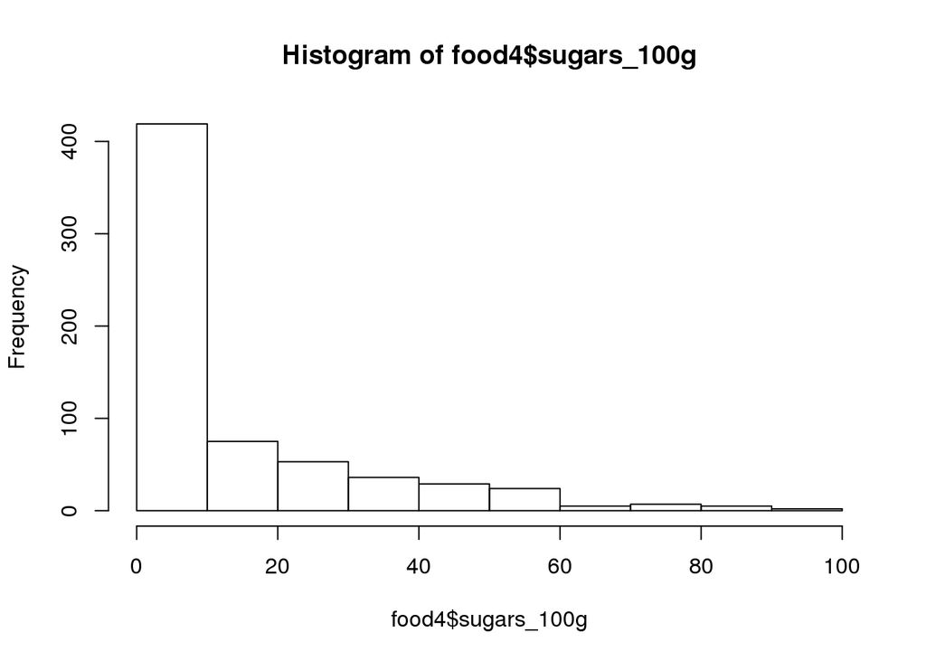

```r
# Create food4
food4 <- food3[food3$sugars_100g != 0, ]

# Create second histogram
hist(food4$sugars_100g)
```

Excluding the observations which don’t contain any sugar, you can better visualie what the underlying distribution looks like.

#### Dealing with messy data

Your analysis of sugar content was so impressive that you’ve now been tasked with determining how many of these foods come in some sort of plastic packaging.

Your dataset has information about packaging, but there’s a bit of a problem: it’s stored in several different languages. This takes messy data to a whole new level! There is no R package to selectively translate, but what if you could jus work with the messy data directly ?

You’re in luck! The root word for *plastic* is same in English (plastic), French (plastique), and Spanish (plastico). To get a general idea of how many of these foods are packaged in plastic, you can look through the `packaging-tags` column for the string `"plasti"`.

```r
# Find entries containing "plasti": plastic
plastic <- str_detect(food3$packaging_tags, "plasti")

# Print the sum of plastic
sum(plastic)
```

[output not shown]

### School Attendance Data

Use all of the tools you’ve learned to import and clean a gnarly dataset containing information on average school attendance in the US.

#### Importing the data

In this chapter, you’ll work with attendance data from public schools in the US, organized by school level and state, during 2007-2008 academic year. The data contain information on average daily attendance (ADA) as a percentage of total enrollment, school day length, and school year length.

The data were given to you in an Excel spreadsheet.

Do you see any symptoms of untidy data ? At first glance, it looks like the first row is a description of the data, the second row is a variable itself that groups multiple columns together, and the fourth row give numbers for the columns, which might look nice in a spreadsheet but isn’t very useful for you, the analyst.

You’ll take it one step at a time to import the data using the `gdata` package. The name of this spreadsheet is `attendance.xls`.

```r
# Load the gdata package
library(gdata)
# Import the spreadsheet: att
att <- read.xls("attendance.xls")
```

#### Examining the data

Now that you’ve successfully imported the data into R, you can get a better idea of how the spreadsheet was read in.

```r
# Print the column names
names(att)
```

```
##  [1] "Table.43..Average.daily.attendance..ADA..as.a.percentage.of.total.enrollment..school.day.length..and.school.year.length.in.public.schools..by.school.level.and.state..2007.08"
##  [2] "X"
##  [3] "X.1"
##  [4] "X.2"
##  [5] "X.3"
##  [6] "X.4"
##  [7] "X.5"
##  [8] "X.6"
##  [9] "X.7"
## [10] "X.8"
## [11] "X.9"
## [12] "X.10"
## [13] "X.11"
## [14] "X.12"
## [15] "X.13"
## [16] "X.14"
## [17] "X.15"
```

```r
# Print the first 6 rows
head(att)
```

```
##   Table.43..Average.daily.attendance..ADA..as.a.percentage.of.total.enrollment..school.day.length..and.school.year.length.in.public.schools..by.school.level.and.state..2007.08
## 1
## 2
## 3                                                                                                                                                                             1
## 4                                                                                                                                                        United States ........
## 5                                                                                                                                                     Alabama .................
## 6                                                                                                                                                     Alaska ..................
##                                                                        X
## 1 Total elementary, secondary, and combined elementary/secondary schools
## 2                                           ADA as percent of enrollment
## 3                                                                      2
## 4                                                                   93.1
## 5                                                                   93.8
## 6                                                                   89.9
##      X.1                         X.2    X.3                         X.4
```

[output cut: 27 more lines]

```r
# Print the last 6 rows
tail(att)
```

```
##                                                                            Table.43..Average.daily.attendance..ADA..as.a.percentage.of.total.enrollment..school.day.length..and.school.year.length.in.public.schools..by.school.level.and.state..2007.08
## 54                                                                                                                                                                                                                             Wisconsin ...............
## 55                                                                                                                                                                                                                             Wyoming .................
## 56                                                                                                                                                                                                                                      †Not applicable.
## 57                                                                                                                                                                                                       ‡Reporting standards not met (too few cases).
## 58 NOTE: Averages reflect data reported by schools rather than state requirements. School-reported length of day may exceed state requirements, and there is a range of statistical error in reported estimates. Standard errors appear in parentheses.
## 59                                                                                                     SOURCE: U.S. Department of Education, National Center for Education Statistics, Schools and Staffing Survey (SASS), \\Public School Questionnaire
##                                                               X    X.1 X.2
## 54                                                         95.0 (0.57) 6.9
## 55                                                         92.4 (1.15) 6.9
## 56
## 57
## 58
## 59 \\ 2003-04 and 2007-08. (This table was prepared June 2011.)
##       X.3 X.4   X.5   X.6   X.7  X.8    X.9 X.10   X.11 X.12   X.13 X.14
## 54 (0.04) 180 (0.7) 1,246 (8.6) 95.4 (0.41)  6.9 (0.05) 93.0 (1.91)  7.0
## 55 (0.05) 175 (1.3) 1,201 (8.3) 92.2 (1.65)  6.9 (0.05) 92.4 (0.75)  7.0
## 56
## 57
## 58
## 59
##      X.15
## 54 (0.14)
## 55 (0.07)
## 56
## 57
## 58
## 59
```

```r
# Print the structure
str(att)
```

```
## 'data.frame':    59 obs. of  17 variables:
##  $ Table.43..Average.daily.attendance..ADA..as.a.percentage.of.total.enrollment..school.day.length..and.school.year.length.in.public.schools..by.school.level.and.state..2007.08: Factor w/ 58 levels "","1","Alabama .................",..: 1 1 2 51 3 4 5 6 7 8 ...
##  $ X                                                                                                                                                                            : Factor w/ 42 levels "","2","\\ 2003-04 and 2007-08. (This table was prepared June 2011.)",..: 42 41 2 22 28 8 6 14 23 2…
##  $ X.1                                                                                                                                                                          : Factor w/ 45 levels "","(0.22)","(0.23)",..: 1 1 1 2 22 21 41 27 14 6 ...
##  $ X.2                                                                                                                                                                          : Factor w/ 14 levels "","3","6.2","6.3",..: 1 14 2 7 11 6 5 10 3 11 ...
##  $ X.3                                                                                                                                                                          : Factor w/ 14 levels "","(0.02)","(0.03)",..: 1 1 1 2 7 5 9 6 7 5 ...
##  $ X.4                                                                                                                                                                          : Factor w/ 15 levels "","171","172",..: 1 15 14 10 10 10 11 9 11 2 ...
##  $ X.5                                                                                                                                                                          : Factor w/ 22 levels "","(0.0)","(0.1)",..: 1 1 1 3 10 21 19 4 6 12 ...
##  $ X.6                                                                                                                                                                          : Factor w/ 48 levels "","1,102","1,117",..: 1 48 47 26 45 15 13 36 5 28 ...
##  $ X.7                                                                                                                                                                          : Factor w/ 48 levels "","(10.1)","(10.3)",..: 1 1 1 36 11 35 22 6 13 48 ...
##  $ X.8                                                                                                                                                                          : Factor w/ 40 levels "","6","81.0",..: 40 39 2 22 20 9 5 13 27 25 ...
##  $ X.9                                                                                                                                                                          : Factor w/ 51 levels "","(0.24)","(0.25)",..: 1 1 1 4 32 25 48 35 20 13 ...
##  $ X.10                                                                                                                                                                         : Factor w/ 14 levels "","6.2","6.3",..: 1 14 10 7 11 5 4 9 3 11 ...
##  $ X.11                                                                                                                                                                         : Factor w/ 13 levels "","(0.02)","(0.03)",..: 1 1 1 2 8 5 10 8 5 7 ...
##  $ X.12                                                                                                                                                                         : Factor w/ 41 levels "","‡","8","85.8",..: 41 40 3 19 35 30 8 18 9 20 ...
##  $ X.13                                                                                                                                                                         : Factor w/ 47 levels "","(†)","(0.35)",..: 1 1 1 7 5 25 43 35 23 20 ...
##  $ X.14                                                                                                                                                                         : Factor w/ 17 levels "","‡","5.9","6.1",..: 1 17 16 9 14 5 7 11 4 13 ...
##  $ X.15                                                                                                                                                                         : Factor w/ 29 levels "","(†)","(0.03)",..: 1 1 1 4 15 13 21 8 18 9 ...
```

These are some messy data! The column names are mostly missing, there are irrelevant notes at the end of the data frame, and it looks like the numeric data were imported as factors.

#### Removing unnecessary rows

You can see that rows 1, 4, 11 and 17 of the spreadsheet are useless. But it safe to do something like the following ?

```
att2 <- att[-c(1, 4, 11, 17),]
```

**No!** From the last exercise, you might have realized that the `read.xls()` function actually imported the first row of the original data frame as the variable name for the first column. Did you notice that the first 6 rows of `att` aren’t the same as the first rows you saw in the original spreadsheet ? What about the 11th and 17th rows?

When you’re importing a messy spreadsheet into R, it’s good practice to compare the original spreadsheet with what you’ve imported. It turns out that, by default, the `read.xls()` function skips empty rows such as the 11th and 17th.

After viewing your data frame, your realize you still need to get rid of the third row of `att`, as well as rows 56 through 59.

```r
# Create remove
remove <- c(3, 56, 57, 58, 59)

# Create att2
att2 <- att[-remove,]
```

#### Removing useless columns

You can see here that the columns 3, 5, 7, 9, 11, 13, 15, 17 don’t contain the values of average daily attendance (ADA). You’ll get rid of them in this exercise.

```r
# Create remove
remove <- seq(3,17,by=2)

# Create att3
att3 <- att2[, - remove]
```

#### Splitting the data

In many cases, a sigle data frame stores multiple “tables” of information. You can often diagnose this problem by looking at the column names and noticing duplicate rows.

In this data frame, columns 1, 6, and 7 represent attendance data for US elementary schools, columns 1, 8, and 9 represent data for secondary schools, and columns 1 through 5 represent data for all schools in the US.

Each of these should be stored as its own separate data frame, so you’ll split them up here.

```r
## att3 is pre-loaded

# Subset just elementary schools: att_elem
att_elem <- att3[,c(1,6,7)]

# Subset just secondary schools: att_sec
att_sec <- att3[,c(1,8,9)]

# Subset all schools: att4
att4 <- att3[,c(1:5)]
```

From here on, you’ll just be working with the data pertaining to all schools in the US.

#### Replacing the names

Since you went through so much trouble finding out which row stored the variable names, you should store that row as the actual column names of the data frame. We’ve modified the names a bit in order to be more stylistically sound; they’re stored as `cnames` in the editor.

This will also allow you to remove the first two rows.

```r
## att4 is pre-loaded

# Define cnames vector (don't change)
cnames <- c("state", "avg_attend_pct", "avg_hr_per_day",
            "avg_day_per_yr", "avg_hr_per_yr")

# Assign column names of att4
colnames(att4) <- cnames

# Remove first two rows of att4: att5
att5 <- att4[-c(1,2),]

# View the names of att5
names(att5)
```

```
## [1] "state"          "avg_attend_pct" "avg_hr_per_day" "avg_day_per_yr"
## [5] "avg_hr_per_yr"
```

#### Cleaning up extra characters

One of the most irritating things about this dataset is that the state names are all stored as the same number of characters, with periods padding the ends of the shorter states. That may be helpful for reading the spreadsheet, but it makes your life harder, so you’ll deal with it in this exercise.

One pitfall to avoid: `.` is a special character in the language of *regular expressions* (regex). In order to specificy that you actually want to remove periods and not their regex equivalent (which is “all characters”), use `\\.`. This is called an “escape” sequence.

```r
# Remove all periods in state column
att5$state <- str_replace_all(att5$state, "\\.", "")

# Remove white space around state names
att5$state <- str_trim(att5$state)

# View the head of att5
head(att5)
```

```
##           state avg_attend_pct avg_hr_per_day avg_day_per_yr avg_hr_per_yr
## 4 United States           93.1            6.6            180         1,193
## 5       Alabama           93.8            7.0            180         1,267
## 6        Alaska           89.9            6.5            180         1,163
## 7       Arizona           89.0            6.4            181         1,159
## 8      Arkansas           91.8            6.9            179         1,229
## 9    California           93.2            6.2            181         1,129
```

#### Some final type conversions

Finally, you’ll convert the values in certain variables to numerics (intead of factors). It’s worth noting that in previous chapters, your numerical data has often come in as character strings. This is just a difference between `read.xls()` and the other import function you’ve used.

The `dplyr` package offers an efficient method for applying a function to many columns at once. Since you might not have taken the `dplyr` course yet, we’re just showing you the code here. You’ll do the some thing, but using subsetting and `sapply()` instead.

```r
# Change columns to numeric using dplyr (don't change)
library(dplyr)
example <- mutate_each(att5, funs(as.numeric), -state)

# Define vector containing numerical columns: cols
cols <- 2:5

# Use sapply to coerce cols to numeric
att5[, cols] <- sapply(att5[, cols], as.numeric)
```